# Quiz 3

Amy Su Jiang

### Question 1

Load the cell segmentation data from the AppliedPredictiveModeling package using the commands:

library(AppliedPredictiveModeling) data(segmentationOriginal) library(caret)

1. Subset the data to a training set and testing set based on the Case variable in the data set.
2. Set the seed to 125 and fit a CART model with the rpart method using all predictor variables and default caret settings.
3. In the final model what would be the final model prediction for cases with the following variable values:
1. TotalIntench2 = 23,000; FiberWidthCh1 = 10; PerimStatusCh1=2
2. TotalIntench2 = 50,000; FiberWidthCh1 = 10;VarIntenCh4 = 100
3. TotalIntench2 = 57,000; FiberWidthCh1 = 8;VarIntenCh4 = 100
4. FiberWidthCh1 = 8;VarIntenCh4 = 100; PerimStatusCh1=2
   1. WS
   2. WS
   3. PS
   4. Not possible to predict
   5. PS
   6. Not possible to predict
   7. PS
   8. Not possible to predict
   9. PS
   10. WS
   11. PS
   12. Not possible to predict
   13. Not possible to predict
   14. WS
   15. PS
   16. PS

```r
library(AppliedPredictiveModeling)
data(segmentationOriginal)
library(caret)
library(rpart)
library(rattle)
set.seed(125)

training <- segmentationOriginal[segmentationOriginal$Case=="Train",]
testing  <- segmentationOriginal[segmentationOriginal$Case=="Test",]

model1  <- train(Class ~ ., method="rpart", training)

model1$finalModel
```

```
## n= 1009
##
## node), split, n, loss, yval, (yprob)
##       * denotes terminal node
##
## 1) root 1009 373 PS (0.63032706 0.36967294)
##   2) TotalIntenCh2< 45323.5 454  34 PS (0.92511013 0.07488987) *
##   3) TotalIntenCh2>=45323.5 555 216 WS (0.38918919 0.61081081)
##     6) FiberWidthCh1< 9.673245 154  47 PS (0.69480519 0.30519481) *
##     7) FiberWidthCh1>=9.673245 401 109 WS (0.27182045 0.72817955) *
```

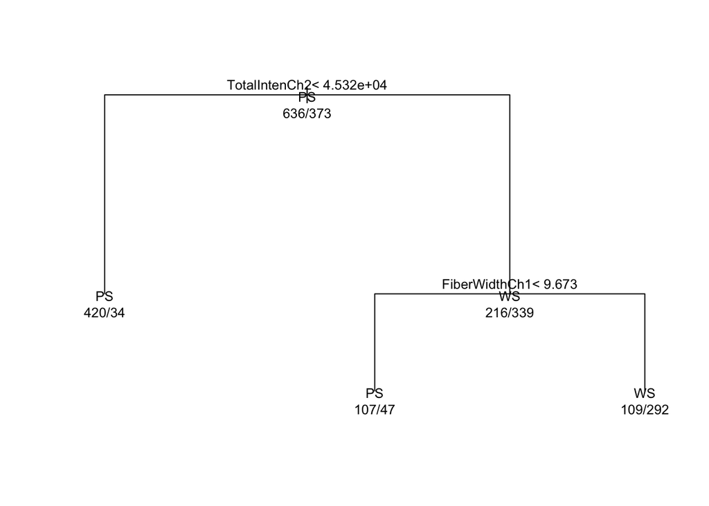

```r
par(xpd = NA)
plot(model1$finalModel)
text(model1$finalModel, use.n = TRUE, all = TRUE, cex = .8)
```

```r
model1.predict <- predict(model1, testing)
confusionMatrix(model1.predict, testing$Class)
```

```
## Confusion Matrix and Statistics
##
##           Reference
## Prediction  PS  WS
##         PS 521  82
##         WS 143 264
##
##                Accuracy : 0.7772
##                  95% CI : (0.7503, 0.8025)
##     No Information Rate : 0.6574
##     P-Value [Acc > NIR] : < 2.2e-16
##
##                   Kappa : 0.5255
##  Mcnemar's Test P-Value : 6.334e-05
##
##             Sensitivity : 0.7846
##             Specificity : 0.7630
##          Pos Pred Value : 0.8640
##          Neg Pred Value : 0.6486
##              Prevalence : 0.6574
##          Detection Rate : 0.5158
##    Detection Prevalence : 0.5970
##       Balanced Accuracy : 0.7738
##
##        'Positive' Class : PS
##
```

### Question 2

If K is small in a K-fold cross validation is the bias in the estimate of out-of-sample (test set) accuracy smaller or bigger? If K is small is the variance in the estimate of out-of-sample (test set) accuracy smaller or bigger. Is K large or small in leave one out cross validation?

```
The bias is smaller and the variance is smaller. Under leave one out cross validation K is equal to the sample size.
The bias is smaller and the variance is bigger. Under leave one out cross validation K is equal to one.
The bias is larger and the variance is smaller. Under leave one out cross validation K is equal to the sample size.
The bias is larger and the variance is smaller. Under leave one out cross validation K is equal to two.
```

[output not shown]

### Question 3

Load the olive oil data using the commands:

library(pgmm) data(olive) olive = olive[,-1]

(NOTE: If you have trouble installing the pgmm package, you can download the olive dataset here: olive_data.zip. After unzipping the archive, you can load the file using the load() function in R.)

These data contain information on 572 different Italian olive oils from multiple regions in Italy. Fit a classification tree where Area is the outcome variable. Then predict the value of area for the following data frame using the tree command with all defaults

newdata = as.data.frame(t(colMeans(olive)))

What is the resulting prediction? Is the resulting prediction strange? Why or why not?

```
0.005291005 0 0.994709 0 0 0 0 0 0. There is no reason why the result is strange.
2.875. There is no reason why this result is strange.
2.875. It is strange because Area should be a qualitative variable - but tree is reporting the average value of Area as a numeric variable in the leaf predicted for newdata
4.59965. There is no reason why the result is strange.
```

```r
library(pgmm)
data(olive)
olive = olive[,-1]
olive$Area  <- as.factor(olive$Area)

inTrain  <-  createDataPartition(olive$Area, p=0.5)[[1]]
training <- olive[inTrain,]
testing <- olive[-inTrain,]

model1 <- train(Area~., method="rpart2", training)
model2 <- train(Area~., method="rpart", training)

model1.predict <- predict(model1, testing)
model2.predict <- predict(model2, testing)

confusionMatrix(model1.predict, testing$Area)
```

```
## Confusion Matrix and Statistics
##
##           Reference
## Prediction   1   2   3   4   5   6   7   8   9
##          1   0   0   0   0   0   0   0   0   0
##          2  12  23   2  14   0   0   0   0   0
##          3   0   5 100   4   0   0   0   2   0
##          4   0   0   0   0   0   0   0   0   0
##          5   0   0   0   0  32   1   0   0   0
##          6   0   0   1   0   0  15   0   0   0
##          7   0   0   0   0   0   0   0   0   0
##          8   0   0   0   0   0   0   0   0   0
##          9   0   0   0   0   0   0  25  23  25
##
## Overall Statistics
##
##                Accuracy : 0.6866
##                  95% CI : (0.6292, 0.7401)
##     No Information Rate : 0.3627
##     P-Value [Acc > NIR] : < 2.2e-16
##
##                   Kappa : 0.6091
##  Mcnemar's Test P-Value : NA
##
## Statistics by Class:
##
##                      Class: 1 Class: 2 Class: 3 Class: 4 Class: 5 Class: 6
## Sensitivity           0.00000  0.82143   0.9709  0.00000   1.0000  0.93750
## Specificity           1.00000  0.89062   0.9392  1.00000   0.9960  0.99627
## Pos Pred Value            NaN  0.45098   0.9009      NaN   0.9697  0.93750
## Neg Pred Value        0.95775  0.97854   0.9827  0.93662   1.0000  0.99627
## Prevalence            0.04225  0.09859   0.3627  0.06338   0.1127  0.05634
## Detection Rate        0.00000  0.08099   0.3521  0.00000   0.1127  0.05282
## Detection Prevalence  0.00000  0.17958   0.3908  0.00000   0.1162  0.05634
## Balanced Accuracy     0.50000  0.85603   0.9551  0.50000   0.9980  0.96688
##                      Class: 7 Class: 8 Class: 9
## Sensitivity           0.00000  0.00000  1.00000
## Specificity           1.00000  1.00000  0.81467
## Pos Pred Value            NaN      NaN  0.34247
## Neg Pred Value        0.91197  0.91197  1.00000
## Prevalence            0.08803  0.08803  0.08803
## Detection Rate        0.00000  0.00000  0.08803
## Detection Prevalence  0.00000  0.00000  0.25704
## Balanced Accuracy     0.50000  0.50000  0.90734
```

```r
confusionMatrix(model2.predict, testing$Area)
```

```
## Confusion Matrix and Statistics
##
##           Reference
## Prediction   1   2   3   4   5   6   7   8   9
##          1   0   0   0   0   0   0   0   0   0
##          2   0   0   0   0   0   0   0   0   0
##          3   0   5 100   4   0   0   0   2   0
##          4   0   0   0   0   0   0   0   0   0
##          5   0   0   1   0  32  16   0   0   0
##          6   0   0   0   0   0   0   0   0   0
##          7   0   0   0   0   0   0   0   0   0
##          8   0   0   0   0   0   0   0   0   0
##          9  12  23   2  14   0   0  25  23  25
##
## Overall Statistics
##
##                Accuracy : 0.5528
##                  95% CI : (0.4929, 0.6116)
##     No Information Rate : 0.3627
##     P-Value [Acc > NIR] : 5.496e-11
##
##                   Kappa : 0.4413
##  Mcnemar's Test P-Value : NA
##
## Statistics by Class:
##
##                      Class: 1 Class: 2 Class: 3 Class: 4 Class: 5 Class: 6
## Sensitivity           0.00000  0.00000   0.9709  0.00000   1.0000  0.00000
## Specificity           1.00000  1.00000   0.9392  1.00000   0.9325  1.00000
## Pos Pred Value            NaN      NaN   0.9009      NaN   0.6531      NaN
## Neg Pred Value        0.95775  0.90141   0.9827  0.93662   1.0000  0.94366
## Prevalence            0.04225  0.09859   0.3627  0.06338   0.1127  0.05634
## Detection Rate        0.00000  0.00000   0.3521  0.00000   0.1127  0.00000
## Detection Prevalence  0.00000  0.00000   0.3908  0.00000   0.1725  0.00000
## Balanced Accuracy     0.50000  0.50000   0.9551  0.50000   0.9663  0.50000
##                      Class: 7 Class: 8 Class: 9
## Sensitivity           0.00000  0.00000  1.00000
## Specificity           1.00000  1.00000  0.61776
## Pos Pred Value            NaN      NaN  0.20161
## Neg Pred Value        0.91197  0.91197  1.00000
## Prevalence            0.08803  0.08803  0.08803
## Detection Rate        0.00000  0.00000  0.08803
## Detection Prevalence  0.00000  0.00000  0.43662
## Balanced Accuracy     0.50000  0.50000  0.80888
```

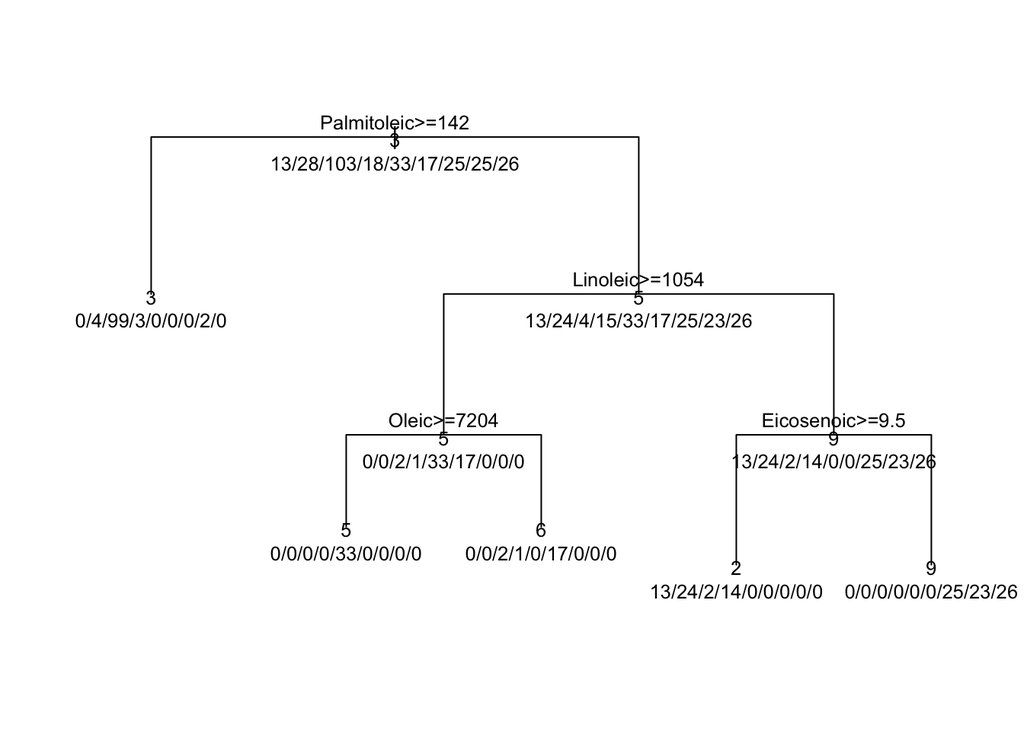

```r
par(xpd=NA)
plot(model1$finalModel)
text(model1$finalModel, all=T, use.n=T, cex=.8)
```

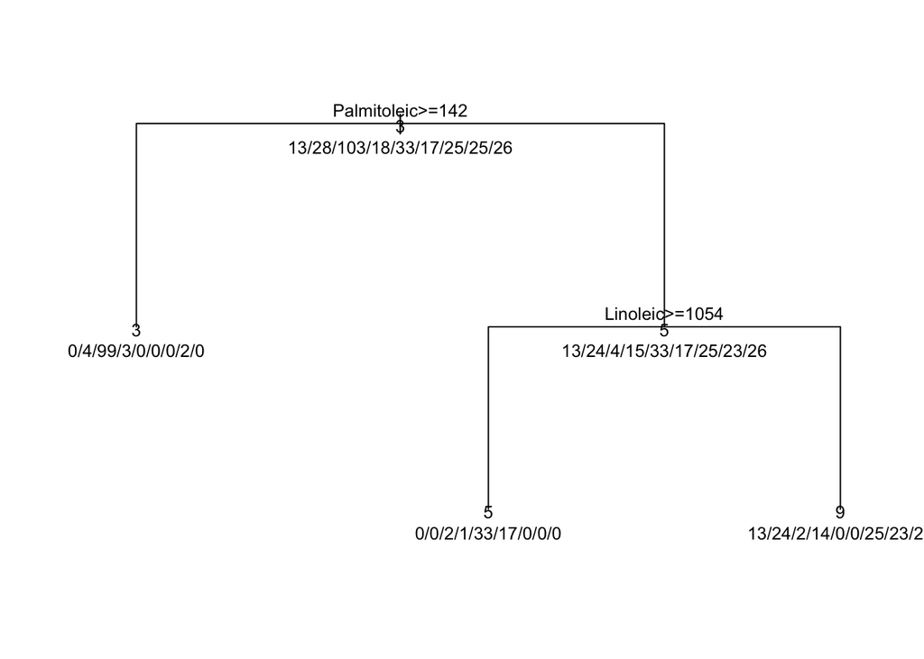

```r
par(xpd=NA)
plot(model2$finalModel)
text(model2$finalModel, all=T, use.n=T, cex=.8)
```

```r
olive$Area  <- as.numeric(olive$Area)
newdata = as.data.frame(t(colMeans(olive)))

predict(model1, newdata)
```

```
## [1] 2
## Levels: 1 2 3 4 5 6 7 8 9
```

### Question 4

Load the South Africa Heart Disease Data and create training and test sets with the following code:

library(ElemStatLearn) data(SAheart) set.seed(8484) train = sample(1:dim(SAheart)[1],size=dim(SAheart)[1]/2,replace=F) trainSA = SAheart[train,] testSA = SAheart[-train,]

Then set the seed to 13234 and fit a logistic regression model (method=“glm”, be sure to specify family=“binomial”) with Coronary Heart Disease (chd) as the outcome and age at onset, current alcohol consumption, obesity levels, cumulative tabacco, type-A behavior, and low density lipoprotein cholesterol as predictors. Calculate the misclassification rate for your model using this function and a prediction on the “response” scale:

missClass = function(values,prediction){sum(((prediction > 0.5)*1) != values)/length(values)}

What is the misclassification rate on the training set? What is the misclassification rate on the test set?

```
Test Set Misclassification: 0.38
Training Set: 0.25
Test Set Misclassification: 0.35
Training Set: 0.31
Test Set Misclassification: 0.31
Training Set: 0.27
Test Set Misclassification: 0.32
Training Set: 0.30
```

```r
library(ElemStatLearn)
data(SAheart)
set.seed(8484)
train = sample(1:dim(SAheart)[1],size=dim(SAheart)[1]/2,replace=F)
trainSA = SAheart[train,]
testSA = SAheart[-train,]

set.seed(13234)
model1 <- train(chd ~ age + alcohol + obesity + tobacco + typea + ldl, method = "glm", family="binomial", data=trainSA)

misClass = function(values,prediction){sum(((prediction > 0.5)*1) != values)/length(values)}

misClass(testSA$chd, predict(model1, testSA))
```

```
## [1] 0.3116883
```

```r
misClass(trainSA$chd, predict(model1, trainSA))
```

```
## [1] 0.2727273
```

### Question 5

Load the vowel.train and vowel.test data sets:

library(ElemStatLearn) data(vowel.train) data(vowel.test)

Set the variable y to be a factor variable in both the training and test set. Then set the seed to 33833. Fit a random forest predictor relating the factor variable y to the remaining variables. Read about variable importance in random forests here: http://www.stat.berkeley.edu/~breiman/RandomForests/cc_home.htm#ooberr The caret package uses by defualt the Gini importance. Calculate the variable importance using the varImp function in the caret package. What is the order of variable importance?

```
The order of the variables is:
x.2, x.1, x.5, x.6, x.8, x.4, x.9, x.3, x.7,x.10
The order of the variables is:
x.2, x.1, x.5, x.8, x.6, x.4, x.3, x.9, x.7,x.10
The order of the variables is:
x.10, x.7, x.9, x.5, x.8, x.4, x.6, x.3, x.1,x.2
The order of the variables is:
x.1, x.2, x.3, x.8, x.6, x.4, x.5, x.9, x.7,x.10
```

```r
library(ElemStatLearn)
data(vowel.train)
data(vowel.test)

set.seed(33833)
vowel.train$y <- factor(vowel.train$y)
vowel.test$y <- factor(vowel.test$y)
model1 <- train(y~., data=vowel.train, method="rf")
varImp(model1)
```

```
## rf variable importance
##
##      Overall
## x.1  100.000
## x.2   99.895
## x.5   45.292
## x.6   30.265
## x.8   25.512
## x.4   10.568
## x.3   10.133
## x.9    9.524
## x.7    6.514
## x.10   0.000
```